# High Risk Borrower/Debtor Detection with Machine Learning

## **Exploratory Data Analysis**

### Check target variable proportion

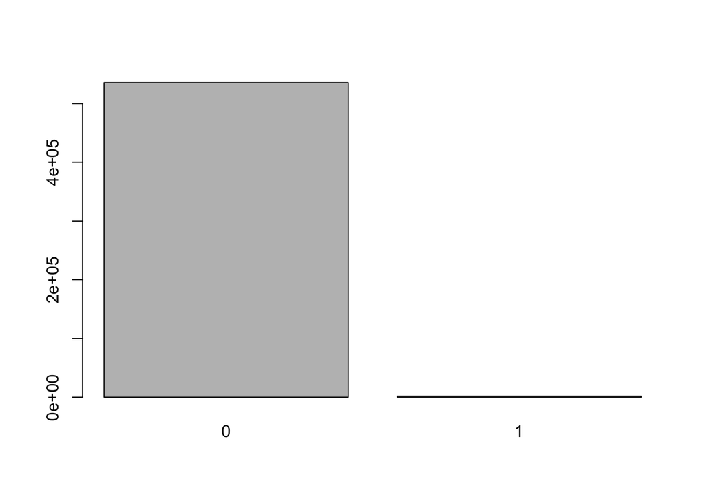

```r
risk$bad_credit %>% table() %>% barplot()
```

> Nuh uh. It’s imbalanced! I will upsample the data!

### Upsampling

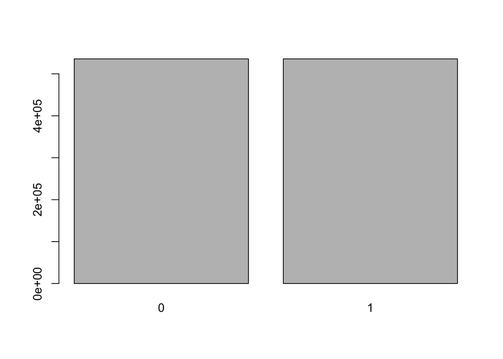

```r
up_risk <- upSample(x = risk%>% select(-bad_credit),
                     y = risk$bad_credit,
                     yname = "bad_credit")

up_risk$bad_credit %>% table() %>% barplot()
```

> Cool! It’s balanced now!

### Inspect categorical columns distributions

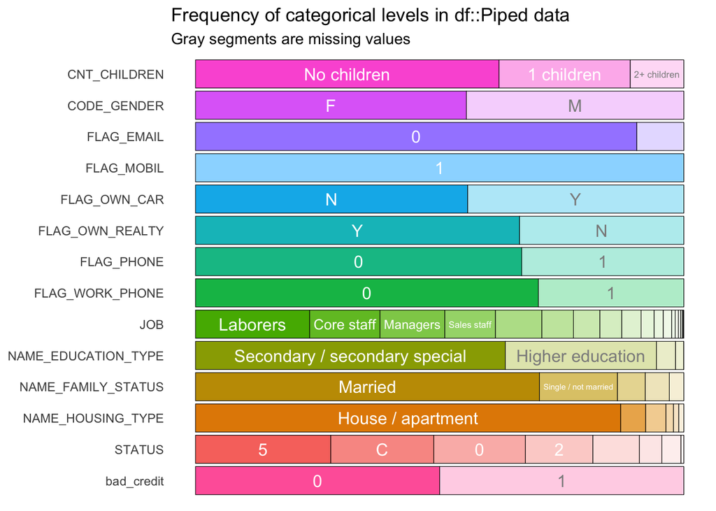

```r
up_risk %>% inspect_cat() %>% show_plot()
```

> FLAG_MOBIL column is all 1, I’m gonna remove it because it’s useless, it won’t provide any information for the model

### Remove uninformative categorical columns

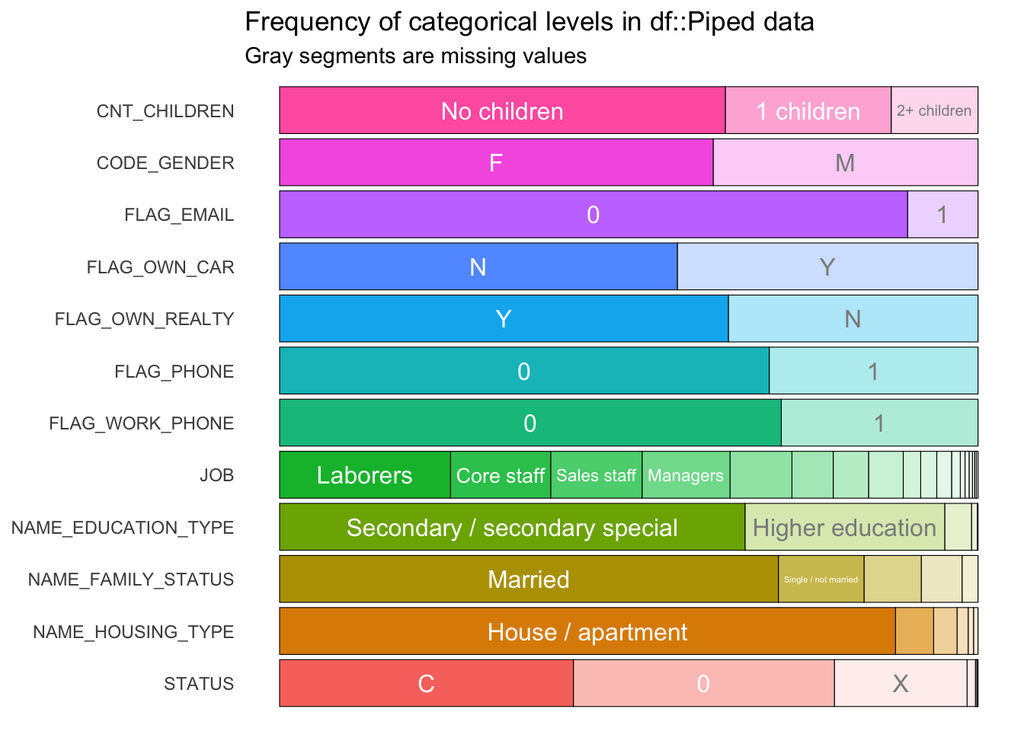

```r
risk <- risk %>% select(-nearZeroVar(.))

risk %>% inspect_cat() %>% show_plot()
```

> Cool! We’re now left with informative categorical columns. Now, let’s explore the numerical columns!

### Inspect numerical columns distributions

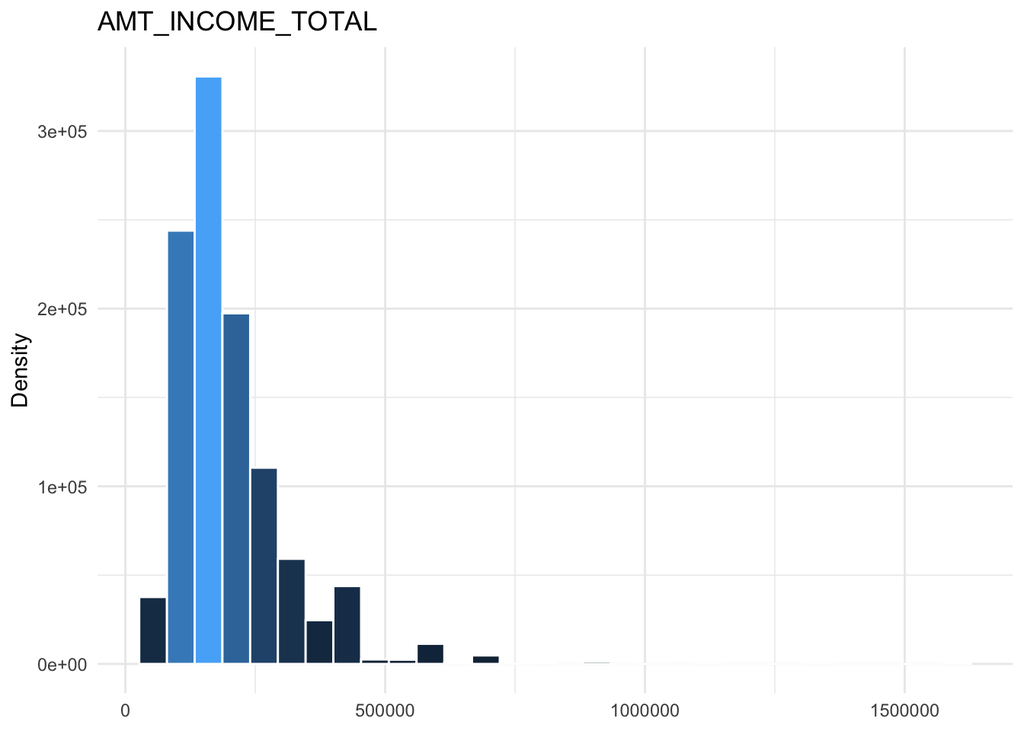

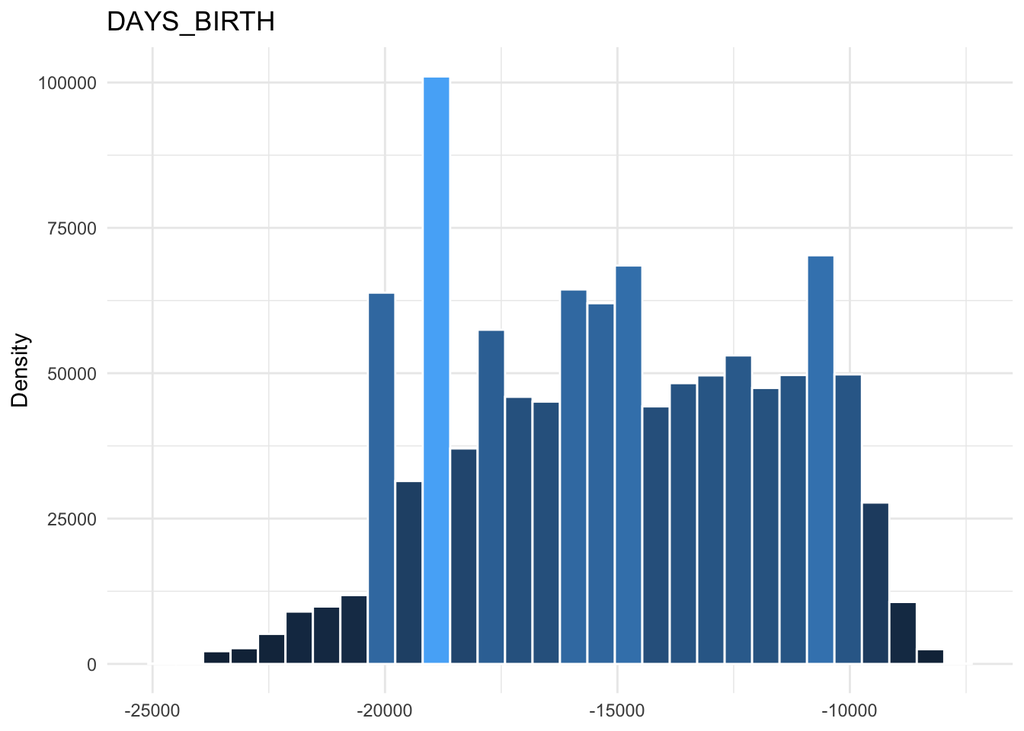

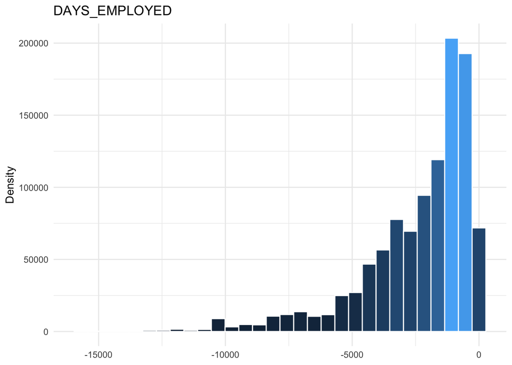

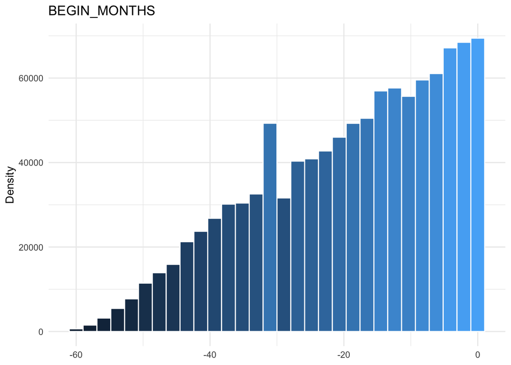

```r
for (col in up_risk %>% select_if(is.numeric) %>% colnames()) {
  print(
    ggplot(up_risk, aes(x = !!sym(col))) +
    geom_histogram(aes(fill = after_stat(density)), col = "white", show.legend = F) +
    labs(x = NULL,
         y = "Density",
         title = paste(col)) +
    theme_minimal()
  )
}
```

## **Cross Validation**

### Set training indices

```r
set.seed(1)

indices <- createDataPartition(y = up_risk$bad_credit,
                               p = 0.8,
                               list = F)
```

### Split train & test

```r
train_data <- up_risk[indices, ]
test_data <- up_risk[-indices, ]

X_train <- train_data %>% select(-bad_credit)
y_train <- train_data$bad_credit

X_test <- test_data %>% select(-bad_credit)
y_test <- test_data$bad_credit
```

## **Model Fitting, Evaluation, and Selection**

### Naive Bayes Algorithm

Because I have large data, I will start with Naive Bayes algorithm because it’s fast like my Bugatti Chiron🏎️⚡

```r
model_nb <- naiveBayes(x = X_train,
                       y = y_train,
                       laplace = 1)
```

### Naive Bayes Model Evaluation

```r
pred_nb <- predict(model_nb, X_test)

confusionMatrix(pred_nb, y_test, positive = "1")
```

```
## Confusion Matrix and Statistics
##
##           Reference
## Prediction      0      1
##          0 107092      0
##          1     49 107141
##
##                Accuracy : 0.9998
##                  95% CI : (0.9997, 0.9998)
##     No Information Rate : 0.5
##     P-Value [Acc > NIR] : < 2.2e-16
##
##                   Kappa : 0.9995
##
##  Mcnemar's Test P-Value : 7.025e-12
##
##             Sensitivity : 1.0000
##             Specificity : 0.9995
##          Pos Pred Value : 0.9995
##          Neg Pred Value : 1.0000
##              Prevalence : 0.5000
##          Detection Rate : 0.5000
##    Detection Prevalence : 0.5002
##       Balanced Accuracy : 0.9998
##
##        'Positive' Class : 1
##
```

> The Naive Bayes model exhibited outstanding `99% Accuracy`, `100% Sensitivity`, and `99% Specificity` in predicting bad credit customers. This is an amazing performace. We don’t necessary need further model fitting, but I’m gonna try using Decision Tree Classifier algorithm because I believe I could get to 100% Accuracy!

### Decision Tree Classifier Algorithm

```r
tree <- ctree_control(mincriterion = 0.9,
                      minsplit = 5,
                      minbucket = 3)

model_dt <- ctree(formula = bad_credit ~ .,
                  data = train_data,
                  control = tree)
```

### Decision Tree Model Evaluation

```r
pred_dt <- predict(model_dt, X_test)

confusionMatrix(pred_dt, y_test, positive = "1")
```

```
## Confusion Matrix and Statistics
##
##           Reference
## Prediction      0      1
##          0 107141      0
##          1      0 107141
##
##                Accuracy : 1
##                  95% CI : (1, 1)
##     No Information Rate : 0.5
##     P-Value [Acc > NIR] : < 2.2e-16
##
##                   Kappa : 1
##
##  Mcnemar's Test P-Value : NA
##
##             Sensitivity : 1.0
##             Specificity : 1.0
##          Pos Pred Value : 1.0
##          Neg Pred Value : 1.0
##              Prevalence : 0.5
##          Detection Rate : 0.5
##    Detection Prevalence : 0.5
##       Balanced Accuracy : 1.0
##
##        'Positive' Class : 1
##
```

> I was right! `100% Accuracy!`

> The decision tree model achieved perfect Accuracy in detecting bad credit customers, making it the winner model of this project! Congratulations to `model_dt`!🥳🤩

## **Conclusion**

In conclusion, the final model has exhibited outstanding performance in predicting bad credit customers. With a perfect Accuracy of 100%, the model demonstrated exceptional precision in classifying both bad and not bad credit cases. The Sensitivity value of 100% further reinforces the model’s efficacy in identifying all instances of bad credit customers, making it an ideal choice for capturing such cases. Moreover, the model’s Specificity of 100% indicates its ability to accurately identify non-bad credit customers. In brief, the decision tree model’s outstanding accuracy of 100% renders it suitable for real-world applications!